In this question we have explored below five asset classes:

- US domestic equities (SPY: the S&P 500 stock index)
- US Treasury bonds (TLT)
- Investment-grade corporate bonds (LQD)
- Emerging-market equities (EEM)
- Real estate (VNQ)

We have taken our data from 2007-01-01. After exploring the data we created three portfolios for these assets assuming we have notional $100,000 to invest in one of these portfolios.

1. Firstly we explored the properties of five assets we are considering.

Installing relevant libraries. Quantmode helps us to download several years of daily data on these ETFs.

```r
library(mosaic)
library(quantmod)
library(foreach)
```

Importing the stocks we are considering

```r
mystocks = c("SPY", "TLT", "LQD","EEM","VNQ")
myprices = getSymbols(mystocks, from = "2007-01-01")
```

[output not shown]

[output not shown]

Adjusting for splits and dividends

```r
SPYa = adjustOHLC(SPY)
TLTa = adjustOHLC(TLT)
LQDa = adjustOHLC(LQD)
EEMa=adjustOHLC(EEM)
VNQa=adjustOHLC(VNQ)
```

Looking at close-to-close changes

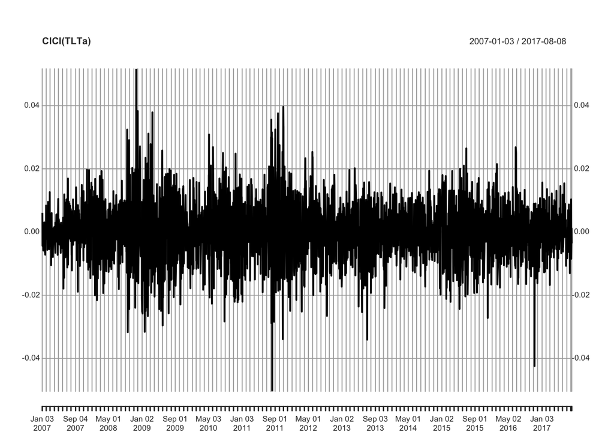

```r
plot(ClCl(TLTa))
```

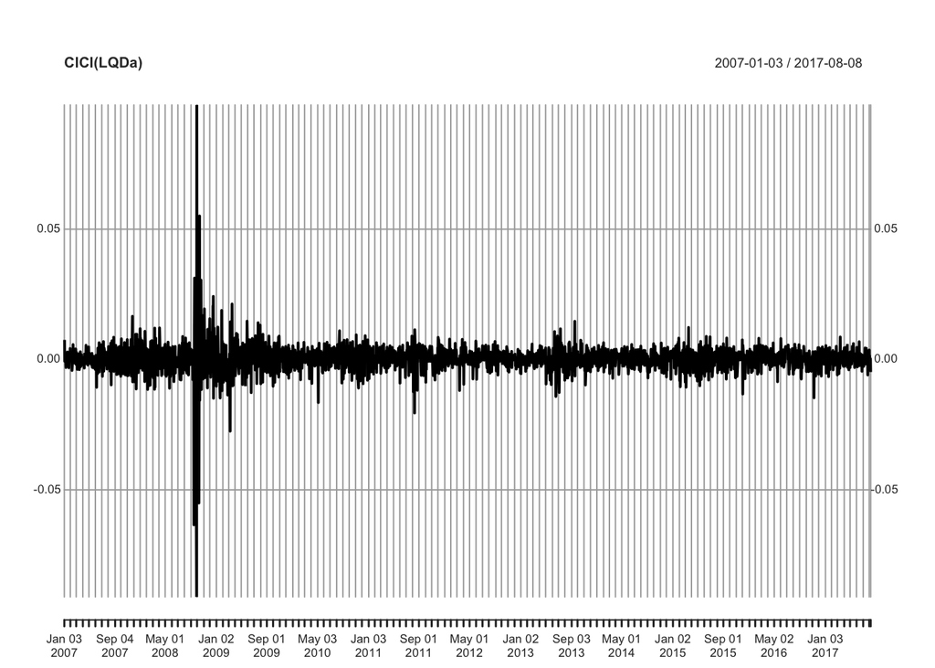

```r
plot(ClCl(LQDa))
```

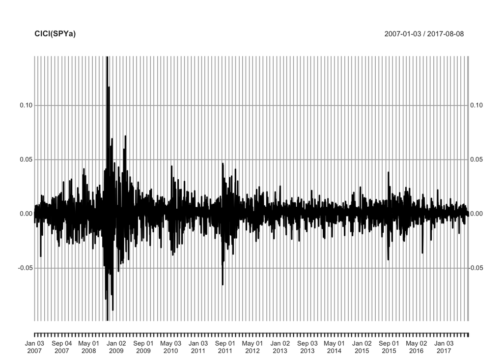

```r
plot(ClCl(SPYa))
```

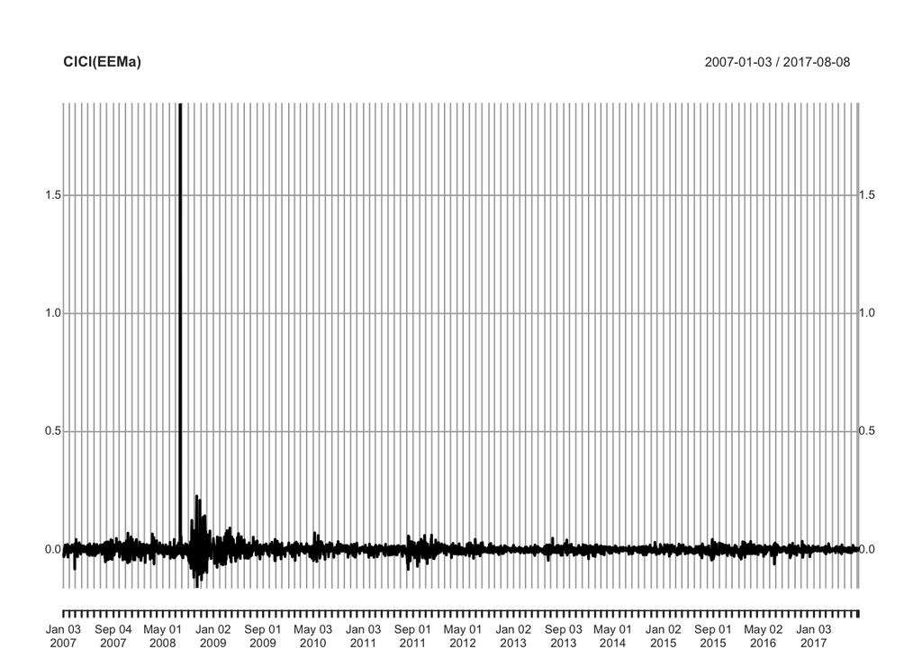

```r
plot(ClCl(EEMa))
```

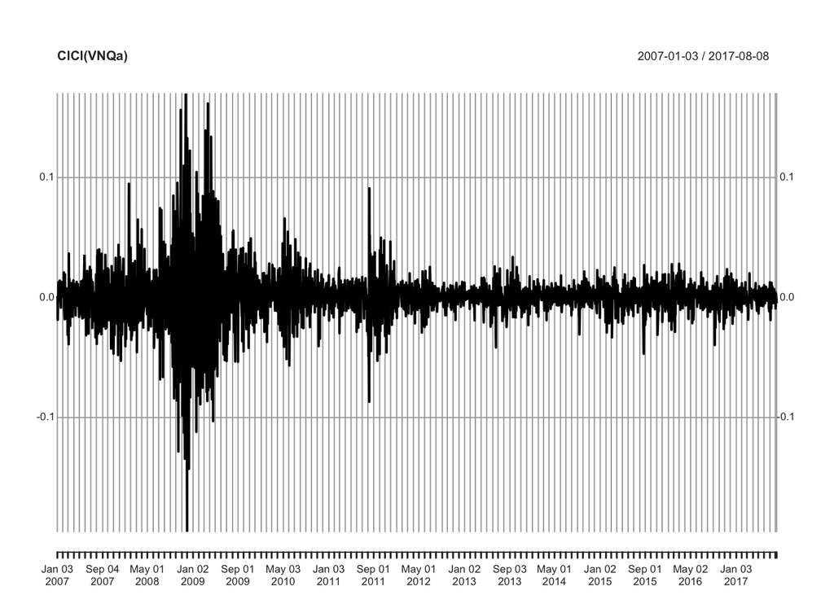

```r
plot(ClCl(VNQa))
```

Combining close to close changes in a single matrix

```r
all_returns = cbind(ClCl(SPYa),ClCl(TLTa),ClCl(LQDa),ClCl(EEMa),ClCl(VNQa))
head(all_returns)
```

```
##                ClCl.SPYa    ClCl.TLTa     ClCl.LQDa    ClCl.EEMa
## 2007-01-03            NA           NA            NA           NA
## 2007-01-04  0.0021221123  0.006063328  0.0075152938 -0.013809353
## 2007-01-05 -0.0079763183 -0.004352668 -0.0006526807 -0.029238205
## 2007-01-08  0.0046250821  0.001793566 -0.0002798843  0.007257535
## 2007-01-09 -0.0008498831  0.000000000  0.0001866169 -0.022336235
## 2007-01-10  0.0033315799 -0.004475797 -0.0013063264 -0.002303160
##               ClCl.VNQa
## 2007-01-03           NA
## 2007-01-04  0.001296655
## 2007-01-05 -0.018518518
## 2007-01-08  0.001451392
## 2007-01-09  0.012648208
## 2007-01-10  0.012880523
```

```r
all_returns = as.matrix(na.omit(all_returns))
```

These returns can be viewed as draws from the joint distribution

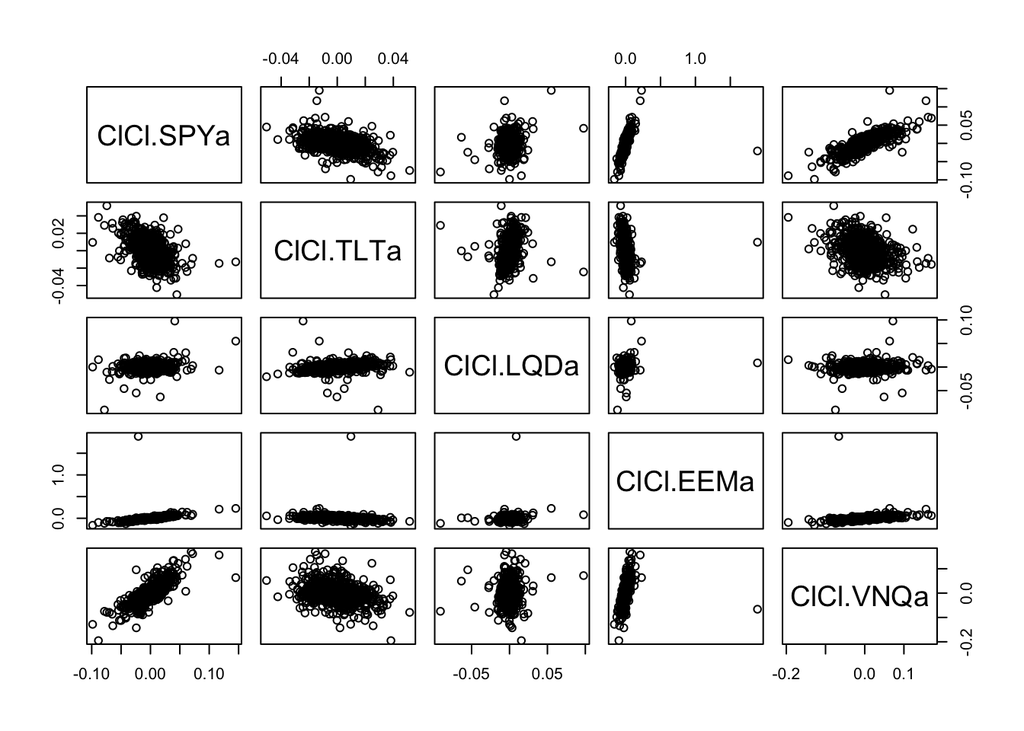

```r
pairs(all_returns)
```

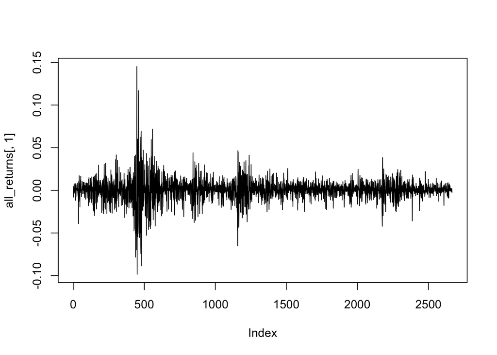

```r
plot(all_returns[,1], type='l')
```

Looking at the market returns over time

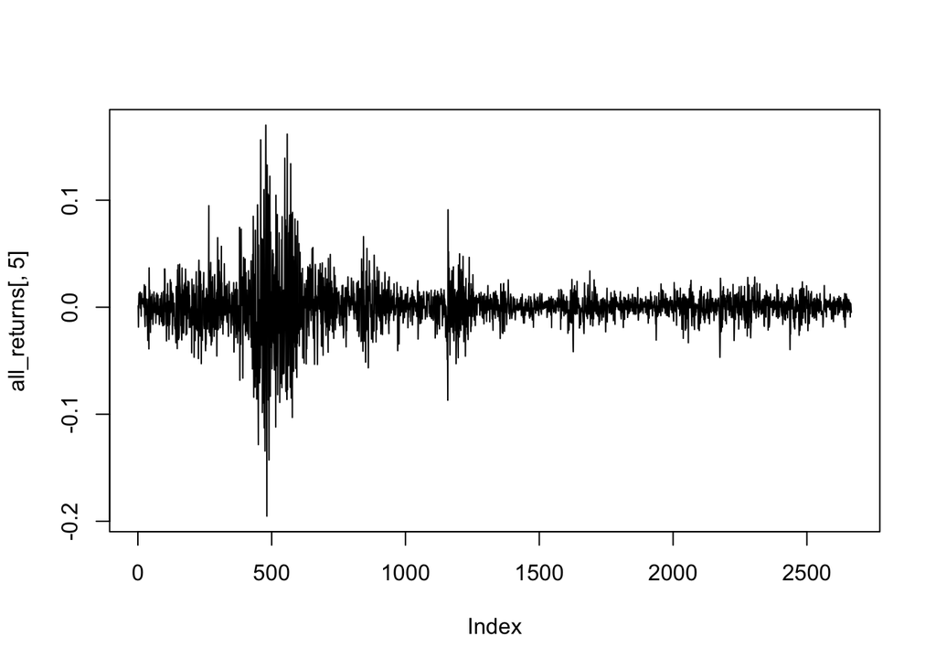

```r
plot(all_returns[,5], type='l')
```

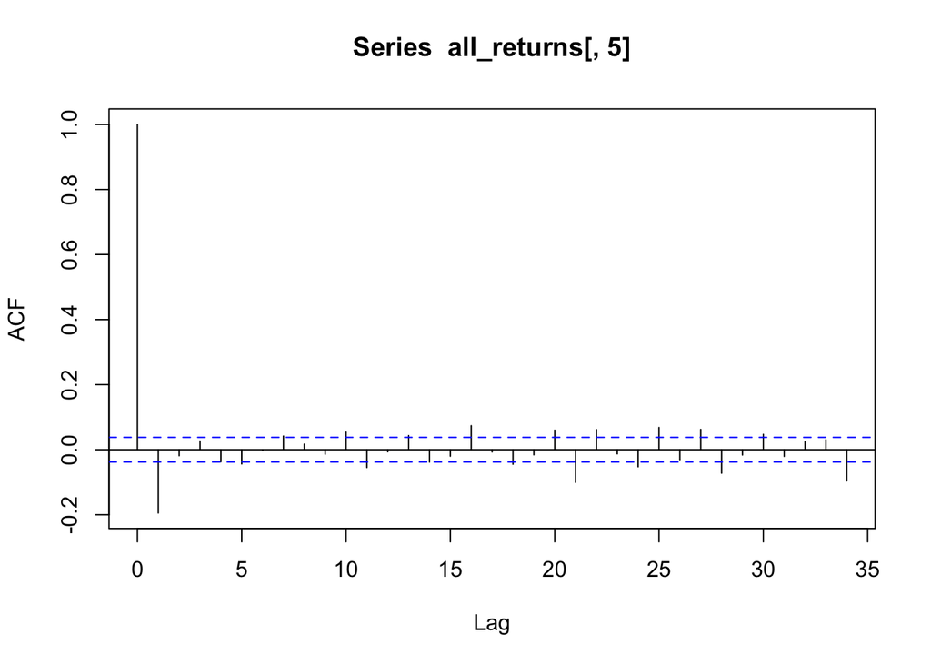

```r
acf(all_returns[,5])
```

The sample correlation matrix

```r
cor(all_returns)
```

```
##            ClCl.SPYa  ClCl.TLTa  ClCl.LQDa   ClCl.EEMa   ClCl.VNQa
## ClCl.SPYa  1.0000000 -0.4434997 0.10255502  0.40329790  0.77671621
## ClCl.TLTa -0.4434997  1.0000000 0.42152439 -0.16857799 -0.26518820
## ClCl.LQDa  0.1025550  0.4215244 1.00000000  0.08802356  0.06704829
## ClCl.EEMa  0.4032979 -0.1685780 0.08802356  1.00000000  0.29130575
## ClCl.VNQa  0.7767162 -0.2651882 0.06704829  0.29130575  1.00000000
```

2. Now we are going to create our first portfolio with even split. We will assign the weight of each asset as 20%.

```r
initial_wealth = 100000
sim1 = foreach(i=1:5000, .combine='rbind') %do% {
  total_wealth = initial_wealth
  weights = c(0.2, 0.2, 0.2, 0.2, 0.2)
  holdings = weights * total_wealth
  n_days = 20
  wealthtracker = rep(0, n_days)
  for(today in 1:n_days) {
    return.today = resample(all_returns, 1, orig.ids=FALSE)
    holdings = holdings + holdings*return.today
    total_wealth = sum(holdings)
    wealthtracker[today] = total_wealth
    weights = c(0.2, 0.2, 0.2, 0.2, 0.2)
    holdings = weights * total_wealth
  }
  wealthtracker
}

head(sim1)
```

```
##               [,1]      [,2]      [,3]      [,4]      [,5]      [,6]
## result.1 100795.12 101297.56 101894.98 102693.36 102505.95 102990.16
## result.2  99765.85  99225.03  99089.76  99790.34  99749.66  99913.49
## result.3  95652.74  96236.28  96306.47  96595.95  96424.07  96798.89
## result.4  99985.59 100201.72  99634.02  98666.45  99837.55 100155.57
## result.5  99619.63  99809.40 100042.45  99906.42  99927.51 100395.32
## result.6  99200.85  99430.03  99872.17 100032.56 100219.13  99986.84
##               [,7]      [,8]      [,9]     [,10]     [,11]     [,12]
## result.1 102073.02 102332.56 102722.89 103245.25 103241.70 103402.24
## result.2  99849.83  98756.49  99533.98  99636.57  99148.90  98931.81
## result.3  96676.68  96542.18  96651.85  95859.47  95762.32  95835.12
## result.4 100210.07 100576.69 100016.32  99722.88  99219.67  99543.37
## result.5  96695.25  96568.23  96875.50  97511.11  97747.56  97220.74
## result.6 100777.74  99637.17  99725.88 100045.85  98735.32  98103.76
##              [,13]     [,14]     [,15]     [,16]     [,17]     [,18]
## result.1 103210.77 103039.02 103103.50 103230.76 103569.27 103463.68
## result.2  98559.25  98909.26  98704.76  99581.70  97642.70  97747.53
## result.3  96700.41  96578.20  96721.13  99062.33  96060.91  95205.48
## result.4 100282.66  99780.97  99949.33 100380.04 100824.97 101575.19
## result.5  97826.75  97865.11  97290.34  96026.47  96204.73  96901.61
## result.6  97801.53  98467.54  97749.64  97201.52  97125.66  97093.15
##              [,19]     [,20]
## result.1 102351.33 102806.46
## result.2  96421.76  96041.02
## result.3  94941.75  95168.88
## result.4 101372.92 101859.12
## result.5  96104.89  96117.67
## result.6  96427.51  96408.27
```

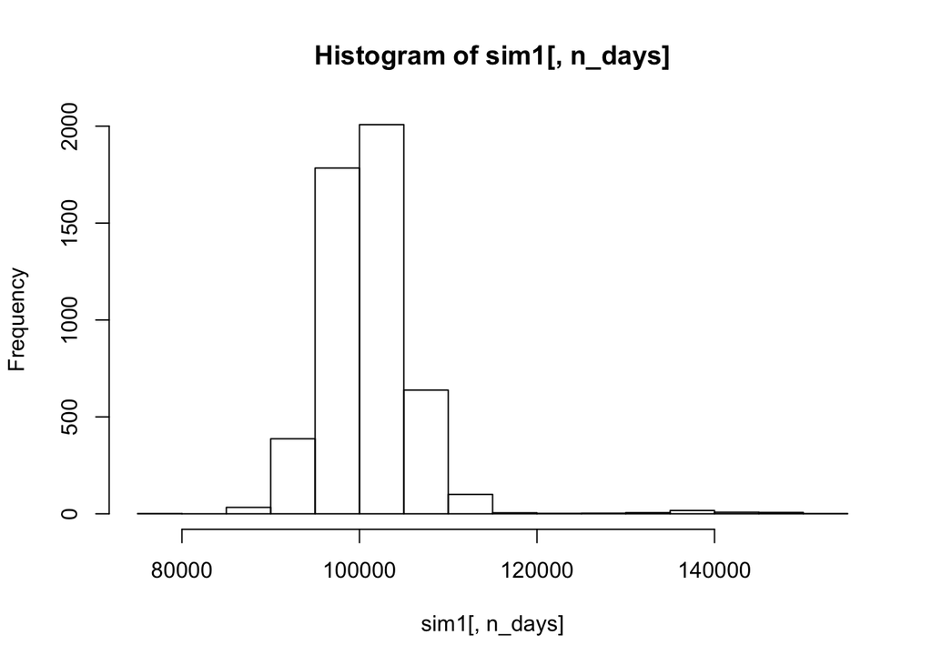

```r
hist(sim1[,n_days], 25)
```

Profit/loss of our portfolio:

```r
mean(sim1[,n_days])
```

```
## [1] 100996.6
```

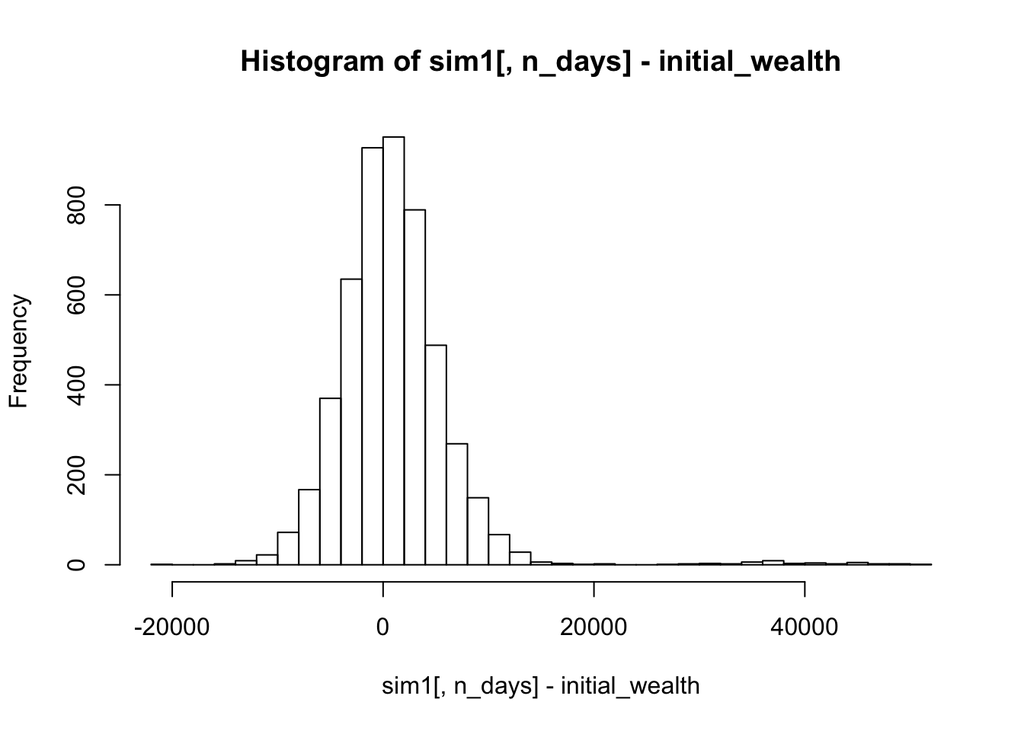

```r
hist(sim1[,n_days]- initial_wealth, breaks=30)
```

Calculating 5% value at risk for this portfolio

```r
quantile(sim1[,n_days], 0.05) - initial_wealth
```

```
##        5%
## -6209.058
```

```r
initial_wealth = 100000
sim1 = foreach(i=1:5000, .combine='rbind') %do% {
  total_wealth = initial_wealth
  weights = c(.2, 0.3, 0.5, 0, 0)
  holdings = weights * total_wealth
  n_days = 20
  wealthtracker = rep(0, n_days)
  for(today in 1:n_days) {
    return.today = resample(all_returns, 1, orig.ids=FALSE)
    holdings = holdings + holdings*return.today
    total_wealth = sum(holdings)
    wealthtracker[today] = total_wealth
    weights = c(.2, 0.3, 0.5, 0, 0)
    holdings = weights * total_wealth
  }
  wealthtracker
}

head(sim1)
```

```
##               [,1]      [,2]      [,3]      [,4]      [,5]      [,6]
## result.1 100503.78 100647.99 100493.81 101905.09 101544.86 101848.47
## result.2  99595.04 100156.75 100401.52 100423.85 100125.04  99857.18
## result.3 100011.28 100464.72 100936.21 100843.35 100524.10  99422.47
## result.4  99923.11  99508.15  99721.94  98928.40  98821.91  98447.82
## result.5  99200.67  99394.93  98702.92  98409.23  98075.38  98113.96
## result.6 100394.90 100232.63  99969.15 100669.76 100961.95  97479.82
##               [,7]      [,8]      [,9]     [,10]     [,11]     [,12]
## result.1 101859.73 101454.42 101182.99 101060.82 101125.54 101314.51
## result.2 100101.22  99803.34 100037.88  99831.48  99808.61  99778.95
## result.3  99713.16  99660.45  99562.45  99250.24  99346.96  99261.97
## result.4  98480.28  98415.74  98488.09  98062.69  98087.81  98423.02
## result.5  98043.14  97915.62  98003.02  97956.82  97723.73  97892.82
## result.6  97007.98  96960.70  97615.87  97374.79  97686.01  97938.82
##              [,13]     [,14]     [,15]     [,16]     [,17]     [,18]
## result.1 101816.20 102086.47 102154.02 101487.15 101388.77 101661.98
## result.2 100476.41 100772.53 100994.46  99191.26  98921.16  98758.00
## result.3  99567.46  99334.29  99282.82  99300.97  99547.15 100027.45
## result.4  98316.10  98325.64  98380.66  98928.30  98702.92  98597.15
## result.5  97972.47  98243.82  97583.74  97802.63  97820.58  98187.06
## result.6  97816.42  98007.97  98723.01  99256.63  99083.68  99301.89
##              [,19]     [,20]
## result.1 100571.68 100539.19
## result.2  99058.72  98772.62
## result.3  99880.57  99864.90
## result.4  97478.52  97517.29
## result.5  97941.54  97765.38
## result.6  99218.03  99312.09
```

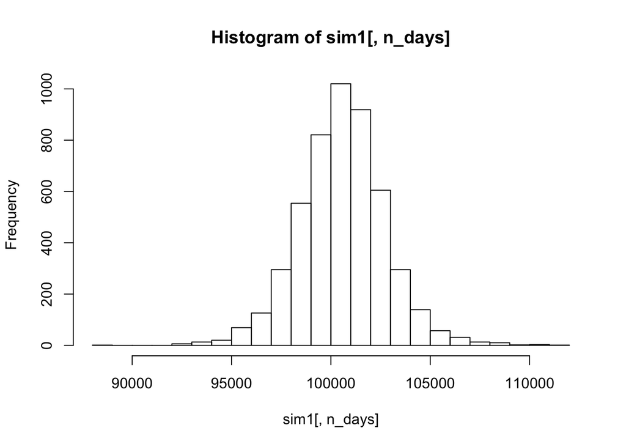

```r
hist(sim1[,n_days], 25)
```

Profit/loss for this portfolio

```r
mean(sim1[,n_days])
```

```
## [1] 100572.7
```

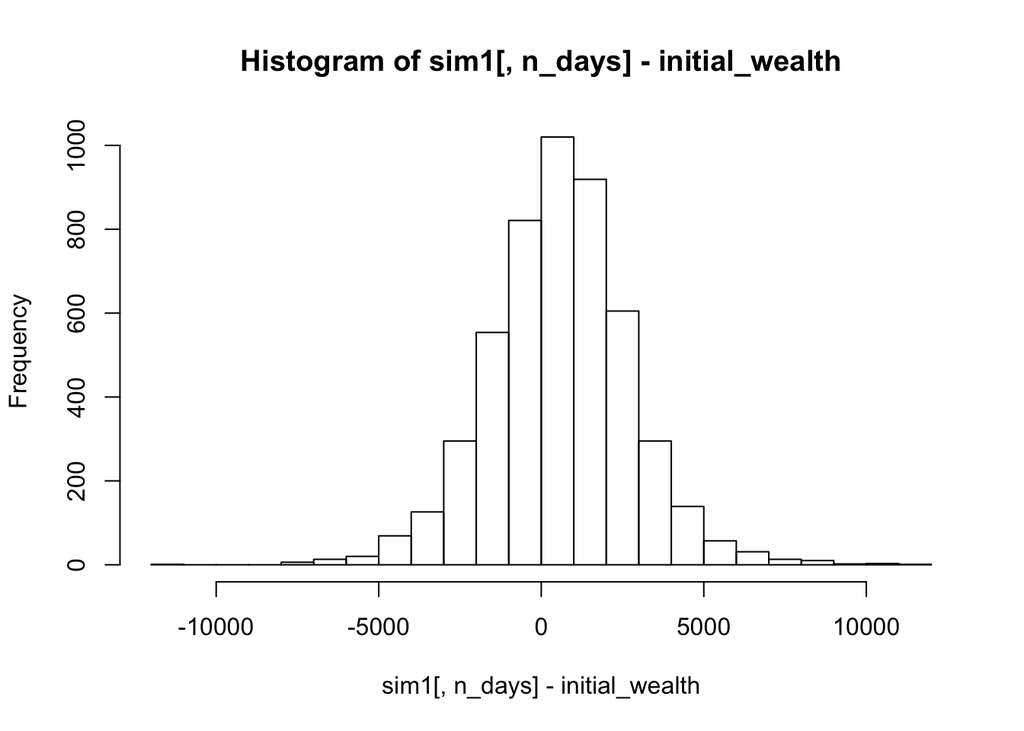

```r
hist(sim1[,n_days]- initial_wealth, breaks=30)
```

Calculating 5% value at risk

```r
quantile(sim1[,n_days], 0.05) - initial_wealth
```

```
##        5%
## -2935.425
```

4. Next we will create an aggressive portfolio which increases our return as well as our risk. Ater trying several combinations, below is the weight we considered for this portfolio:

TLT - 0% LQD - 0% SPY - 0% EEM - 90% VMQ - 10%

```r
initial_wealth = 100000
sim1 = foreach(i=1:5000, .combine='rbind') %do% {
  total_wealth = initial_wealth
  weights = c(0, 0, 0, .9, .1)
  holdings = weights * total_wealth
  n_days = 20
  wealthtracker = rep(0, n_days)
  for(today in 1:n_days) {
    return.today = resample(all_returns, 1, orig.ids=FALSE)
    holdings = holdings + holdings*return.today
    total_wealth = sum(holdings)
    wealthtracker[today] = total_wealth
    weights = c(0, 0, 0, .9, .1)
    holdings = weights * total_wealth
  }
  wealthtracker
}

head(sim1)
```

```
##               [,1]      [,2]      [,3]      [,4]      [,5]      [,6]
## result.1  99852.98 100525.10  93063.93  93135.97  92254.49  94330.77
## result.2  98452.19  98019.43  97613.76  98309.09  99285.95 100545.26
## result.3  97031.72 101181.92  99737.94  98014.14  96959.00  97948.93
## result.4 101374.43 100807.02 102215.47 104191.97 105082.02 107146.72
## result.5 102099.52 102347.60 103233.26 103667.44 106343.75 107713.42
## result.6  99674.58 100589.71 100403.04 100619.25  99216.16 101475.67
##               [,7]      [,8]      [,9]     [,10]     [,11]     [,12]
## result.1  94676.65  94632.21  95544.95  95595.78  93910.33  93938.67
## result.2 100472.27 103073.38 102642.10 107074.45 110815.41 109404.15
## result.3 110369.70 110905.93 112432.77 112013.53 110367.41 112985.48
## result.4 103817.90 105709.12 104387.65 104941.49 105322.46 105086.70
## result.5 108013.39 109573.79 110108.34 110169.76 109309.85 108501.99
## result.6 101256.74 101898.74 101851.88 101149.98 101522.34 102771.28
##              [,13]     [,14]     [,15]     [,16]     [,17]     [,18]
## result.1  94031.47  92694.01  91638.54  92366.82  92800.61  93041.14
## result.2 105894.66 105752.72 107934.01 109192.04 110568.27 108552.01
## result.3 107683.44 108626.36 111454.78 109626.48 110035.43 106138.71
## result.4 106053.93 109243.22 110199.80 107816.92 108353.88 108551.08
## result.5 107057.05 106678.26 107920.57 108662.96 108430.41 109069.96
## result.6 102613.95 105078.38 101914.33 102944.17 100459.70 102768.79
##              [,19]     [,20]
## result.1  92476.04  93218.13
## result.2 106878.84 108363.43
## result.3 103109.92 103831.56
## result.4 109335.58 108779.59
## result.5 110478.43 111345.47
## result.6 102866.29 104772.37
```

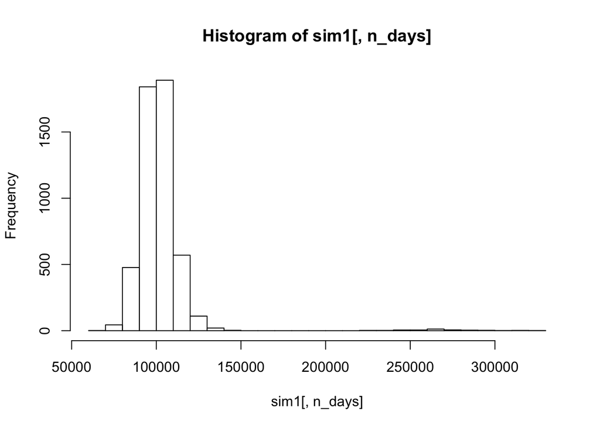

```r
hist(sim1[,n_days], 25)
```

Profit/loss for this portfolio

```r
mean(sim1[,n_days])
```

```
## [1] 102234.3
```

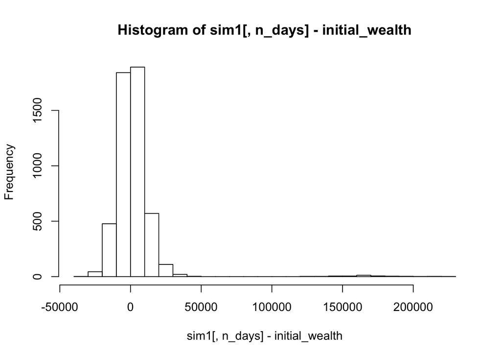

```r
hist(sim1[,n_days]- initial_wealth, breaks=30)
```

Calculating 5% value at risk

```r
quantile(sim1[,n_days], 0.05) - initial_wealth
```

```
##        5%
## -13528.09
```